# Machine Learning - Human Activity Recognition

Joost van Brakel

November 20, 2015

# Executive summary

The data for this project come from this source: http://groupware.les.inf.puc-rio.br/har. If you use the document you create for this class for any purpose please cite them as they have been very generous in allowing their data to be used for this kind of assignment.

Read more: http://groupware.les.inf.puc-rio.br/har#ixzz3s7lvMhWN

We utilized the knowledge generated from the paper above and focused on evluating four methods and random forest method provided most accurate report, which accurancy in the 99%

# Process

For this analysis we used R and a number of key libraries, namely : xtable, AppliedPredictiveModeling, caret, randomForest, rpart, knitr,htmlTable and doMC

# Data

The training data for this project are available here:

https://d396qusza40orc.cloudfront.net/predmachlearn/pml-training.csv

The test data are available here:

https://d396qusza40orc.cloudfront.net/predmachlearn/pml-testing.csv

Participants were asked to perform one set of 10 repetitions of the Unilateral Dumbbell Biceps Curl in five different fashions: exactly according to the specification (Class A), throw- ing the elbows to the front (Class B), lifting the dumbbell only halfway (Class C), lowering the dumbbell only halfway (Class D) and throwing the hips to the front (Class E).

# Processing

The training dataset was split in to 70% training, 30% validation

```r
URL <- "https://d396qusza40orc.cloudfront.net/predmachlearn/pml-training.csv"
download.file(URL, destfile = "pml-training.csv", method="curl")

URL <- "https://d396qusza40orc.cloudfront.net/predmachlearn/pml-testing.csv"
download.file(URL, destfile = "pml-testing.csv", method="curl")

training <- read.csv("pml-training.csv",na.strings = "NA")
testing <- read.csv("pml-testing.csv",na.strings = "NA")

training[,7:159] <- sapply(training[,7:159],as.numeric)
testing[,7:159] <- sapply(testing[,7:159], as.numeric)

# remove columns that will not be used in prediction
training <- training[8:160]
testing <- testing[8:160]

# remove na columns in testing set from both testing and training.
nas <- is.na(apply(testing,2,sum))
testing <- testing[,!nas]
training <- training[,!nas]


colDesc <- getFractionMissing(training)
filteredCol <- colDesc[colDesc$FractionMissing < .9,1]
training2 <- training[,filteredCol]
testing2 <- testing[,filteredCol]

set.seed(1313)
# divide training set in training and validation
inTrain <- createDataPartition(y=training2$classe, p=0.7, list=FALSE)
trainSet <- training2[inTrain,]
valSet <- training2[-inTrain,]
```

# Modeling performance, selection and validation

Based on the previous analysis performed on this dataset, which was documented with the attached link, this dataset best responds to tree based predictions.

To determine the best modeling approach we examined 4 approaches  
1. Recursive Partitioning and Regression Trees results (rpart)  
2. Random Forest (rf)  
3. Generalized Boosted Models (gbm)  
4. Treebag (treebag)

We used A 3-fold cross-validation to estimate the out of sample error, we tried a number of folds, we provided the comparison below between 2,3 and 4 folD, no material difference existed therefore we selected the midde option (3 fold)

```r
# model - Recursive Partitioning and Regression Trees
modRPATFit <- train(classe ~.,data=trainSet, method="rpart")
pred0 <- predict(modRPATFit, newdata = valSet)
cm0 <- confusionMatrix(pred0, valSet$classe)

#model -  Random Forest
modelRFFit <- train(classe ~., data=trainSet, method="rf",na.action = na.omit, allowParallel=TRUE, trControl = trainControl(method = "cv", number = 3, allowParallel = TRUE))
pred1 <- predict(modelRFFit, newdata = valSet)
cm1 <- confusionMatrix(pred1, valSet$classe)

#model -  Generalized Boosted Models
modelGBMFit <- train(classe ~., data=trainSet, method="gbm",na.action = na.omit, trControl = trainControl(method = "cv", number = 3),verbose = FALSE)
pred2 <- predict(modelGBMFit, newdata = valSet)
cm2 <- confusionMatrix(pred2, valSet$classe)

#model -  treebag
modelBAGFit <- train(classe ~., data=trainSet, method="treebag",na.action = na.omit, trControl = trainControl(method = "cv", number = 3),verbose = FALSE)
pred3 <- predict(modelBAGFit, newdata = valSet)
cm3 <- confusionMatrix(pred3, valSet$classe)

results_test <-rbind(
      list("rpart", cm0$overall[1]),
      list("rf", cm1$overall[1]),
      list("gbm", cm2$overall[1]),
      list ("treebag",cm3$overall[1])
)

# added readable column headers
colnames(results_test) <- c("Method", "Accuracy")

# export results to table
tab_Q1 <-xtable(results_test, caption = "Results by method")
print(tab_Q1, floating=TRUE, caption.placement="top", type="html")
```

Results by method

|  | Method | Accuracy |
| --- | --- | --- |
| 1 | rpart | 0.50 |
| 2 | rf | 0.99 |
| 3 | gbm | 0.96 |
| 4 | treebag | 0.91 |

```r
#model -  Random Forest - 2-fold Cross validatio
modelRFFit1 <- train(classe ~., data=trainSet, method="rf",na.action = na.omit, allowParallel=TRUE, trControl = trainControl(method = "cv", number = 2, allowParallel = TRUE))
pred1a <- predict(modelRFFit1, newdata = valSet)
cm1a <- confusionMatrix(pred1a, valSet$classe)

#model -  Random Forest - 4-fold Cross validatio
modelRFFit2 <- train(classe ~., data=trainSet, method="rf",na.action = na.omit, allowParallel=TRUE, trControl = trainControl(method = "cv", number = 4, allowParallel = TRUE))
pred1b <- predict(modelRFFit2, newdata = valSet)
cm1b <- confusionMatrix(pred1b, valSet$classe)

results_test <-rbind(
      list("2-fold", cm1a$overall[1]),
      list("3-fold", cm1$overall[1]),
      list("4-fold",cm1b$overall[1])
)

# added readable column headers
colnames(results_test) <- c("Method", "Accuracy")

# export results to table
tab_Q2 <-xtable(results_test, caption = "Random forest results by fold")
print(tab_Q2, floating=TRUE, caption.placement="top", type="html")
```

Random forest results by fold

|  | Method | Accuracy |
| --- | --- | --- |
| 1 | 2-fold | 0.99 |
| 2 | 3-fold | 0.99 |
| 3 | 4-fold | 0.99 |

# Predictions

The RF methods provides the strongest test on an accuracy basis, if we look at the figures below, you can see in the confusion Matrix, that the larges out of sample error is within D, which means that D will be the most challenging to forecast

```r
varImp(modelRFFit)
```

```
## rf variable importance
##
##   only 20 most important variables shown (out of 52)
##
##                   Overall
## roll_belt          100.00
## yaw_belt            87.31
## magnet_dumbbell_z   72.22
## magnet_dumbbell_y   69.61
## pitch_belt          64.34
## pitch_forearm       63.49
## magnet_dumbbell_x   58.03
## roll_forearm        54.37
## accel_belt_z        50.57
## magnet_belt_z       49.32
## accel_dumbbell_y    47.88
## roll_dumbbell       43.44
## magnet_belt_y       43.32
## accel_dumbbell_z    42.61
## roll_arm            34.75
## accel_forearm_x     34.22
## gyros_belt_z        34.14
## yaw_dumbbell        31.20
## accel_dumbbell_x    30.36
## magnet_arm_x        30.32
```

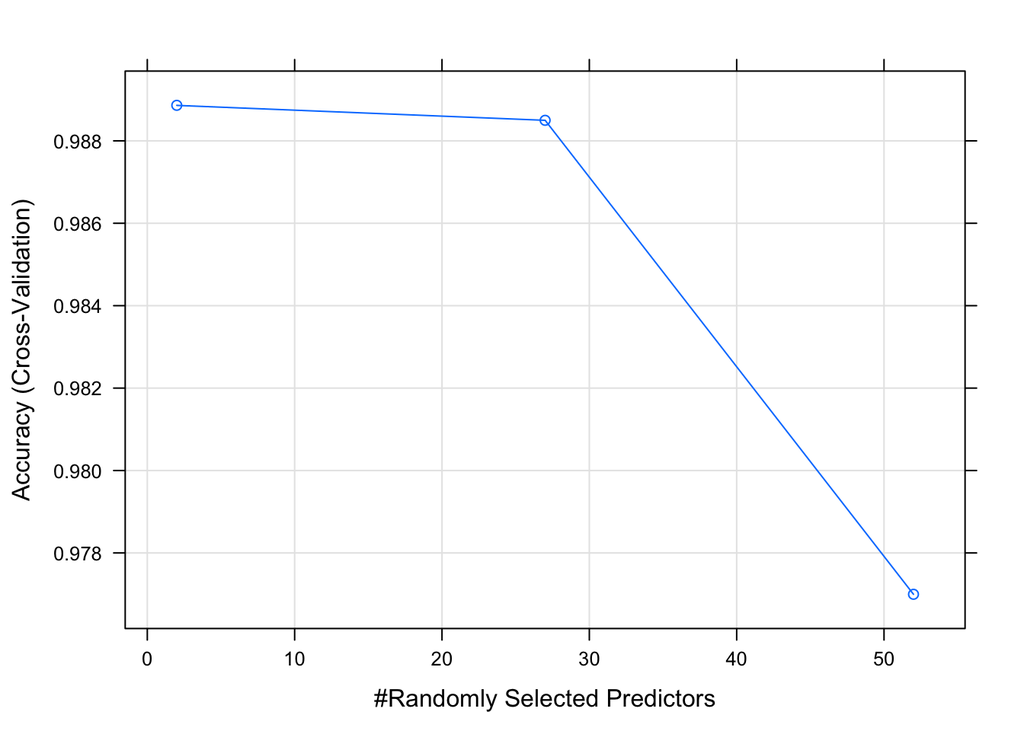

```r
plot(modelRFFit)
```

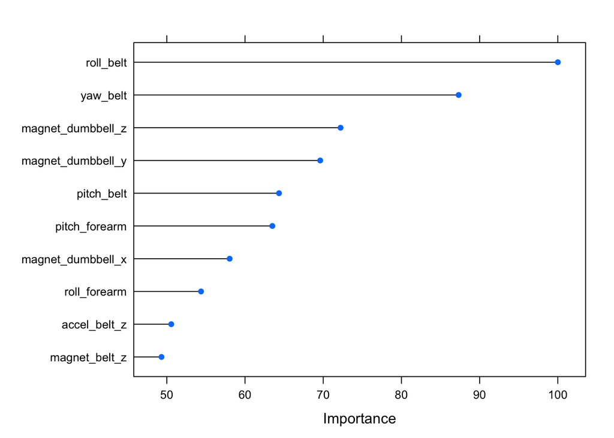

```r
plot(varImp(modelRFFit), top = 10)
```

```r
tab_Q3 <-xtable(cm1$table, caption = "final results - confusion matrix")
print(tab_Q3, floating=TRUE, caption.placement="top", type="html")
```

final results - confusion matrix

|  | A | B | C | D | E |
| --- | --- | --- | --- | --- | --- |
| A | 1674 | 4 | 0 | 0 | 0 |
| B | 0 | 1133 | 5 | 0 | 0 |
| C | 0 | 2 | 1020 | 17 | 0 |
| D | 0 | 0 | 1 | 946 | 1 |
| E | 0 | 0 | 0 | 1 | 1081 |

```r
cm1
```

```
## Confusion Matrix and Statistics
##
##           Reference
## Prediction    A    B    C    D    E
##          A 1674    4    0    0    0
##          B    0 1133    5    0    0
##          C    0    2 1020   17    0
##          D    0    0    1  946    1
##          E    0    0    0    1 1081
##
## Overall Statistics
##
##                Accuracy : 0.9947
##                  95% CI : (0.9925, 0.9964)
##     No Information Rate : 0.2845
##     P-Value [Acc > NIR] : < 2.2e-16
##
##                   Kappa : 0.9933
##  Mcnemar's Test P-Value : NA
##
## Statistics by Class:
##
##                      Class: A Class: B Class: C Class: D Class: E
## Sensitivity            1.0000   0.9947   0.9942   0.9813   0.9991
## Specificity            0.9991   0.9989   0.9961   0.9996   0.9998
## Pos Pred Value         0.9976   0.9956   0.9817   0.9979   0.9991
## Neg Pred Value         1.0000   0.9987   0.9988   0.9964   0.9998
## Prevalence             0.2845   0.1935   0.1743   0.1638   0.1839
## Detection Rate         0.2845   0.1925   0.1733   0.1607   0.1837
## Detection Prevalence   0.2851   0.1934   0.1766   0.1611   0.1839
## Balanced Accuracy      0.9995   0.9968   0.9951   0.9905   0.9994
```

# Forecasting